# INFORME PARA ANALIZAR, IDENTIFICAR, INFORMAR Y PREVENIR LA SINIESTRALIDAD VIAL EN EL ATLÁNTICO CON UN ESTUDIO ENFOCADO EN LA CULTURA DE MOVILIDAD EN BARRANQUILLA (2020-2024)

Data Vial Analytics

2025-10-15

```r
library(tidyverse)
library(scales)
library(readxl)
library(dplyr)
library(ggrepel)
library(htmltools)#Evita que las etiquetas en los gráficos se sobrepongan.
library(stringr)# Cambiar fuente global y color de texto en ggplot
library(leaflet)
library(ggplot2)
library(sf)
library(reticulate)
```

```r
siniestro_fall <- read_excel("C:\\Users\\ADMIN.PC_ADMIN\\Downloads\\Siniestros_Atlántico_2020_2024.xlsx",
    sheet = "Fallecidos")

siniestro_les <- read_excel("C:\\Users\\ADMIN.PC_ADMIN\\Downloads\\Siniestros_Atlántico_2020_2024.xlsx",
    sheet = "Lesionados")
```

### CANTIDAD TOTAL DE FALLECIDOS POR SINIESTRALIDAD VIAL EN EL DEPARTAMENTO DEL ATLÁNTICO (2020-2024)

```r
limite_oest=min(siniestro_fall$X)
limite_este=max(siniestro_fall$X)
limite_sur=min(siniestro_fall$Y)
limite_norte=max(siniestro_fall$Y)
siniestro_fall %>%
leaflet()%>%
  addTiles()%>%
  fitBounds(
    lng1= limite_oest,
    lat1= limite_sur,
    lng2 = limite_este,
    lat2 = limite_norte
  )%>%
  addMarkers(
    lng = ~X,
    lat = ~Y,
    clusterOptions = markerClusterOptions(),
    popup = siniestro_fall$Municipio_Ubicacion
  )
```

[interactive chart not shown]

### CANTIDAD TOTAL DE LESIONADOS POR SINIESTRALIDAD VIAL EN EL DEPARTAMENTO DEL ATLÁNTICO (2020-2024)

Con un total de 3007 acumulado en el departamento, es la cantidad de siniestros en donde resultan las victimas lesionadas en el Atlántico 3.3 veces mayor que la cantidad de siniestros con victimas fallecidas. Como se puede apreciar, los factores socioeconómicos -Mayor cantidad de empresas, población, y flujo vehicular- siguen la misma tendencia ocurrida en el anterior gráfico, donde Barranquilla es el epicentro de los siniestros de tránsito y la periferia donde menos ocurren. Comparando Barranquilla con Baranoa, no solo que la diferencia es de 2523, si no que también representa que Barranquilla ocurren 53.5 veces más siniestros con victimas lesionadas que Baranoa.

```r
siniestro_les%>%
  leaflet()%>%
  addTiles()%>%
  addMarkers(
    lng=~X,
    lat = ~Y,
    clusterOptions = markerClusterOptions(),
    popup = siniestro_fall$Municipio_Ubicacion
  )
```

[interactive chart not shown]

### LESIONADOS POR SINIESTRALIDAD VIAL DE ACUERDO AL TIPO DE CIRCUNSTANCIA EN EL DEPARTAMENTO DEL ATLÁNTICO (2020-2024)

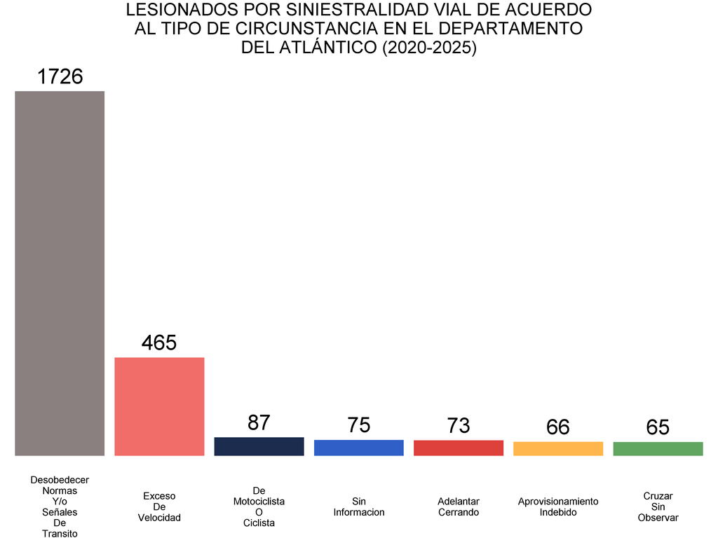

```r
tabla_les_1 <- siniestro_les %>%
  filter(Departamento_Ubica == "ATLÁNTICO")%>%
  group_by(Circunstancia) %>%
  summarise(Circunstancia_les =n(),.groups ="drop")%>%
  arrange(desc(Circunstancia_les))%>%
  mutate(Circunstancia = str_wrap(Circunstancia, width = 5))%>%
  top_n(7)

title_1 <- str_wrap("LESIONADOS POR SINIESTRALIDAD VIAL DE ACUERDO AL TIPO DE CIRCUNSTANCIA EN EL DEPARTAMENTO DEL ATLÁNTICO (2020-2025)", width= 45)

colores_fins <- c("#DE403B", "#FFB74D", "#60A560", "#1C2C4E","#8A8080","#F06D69","#3060C7","#36D636","#E38C0B", "#A6514E")


ggplot(tabla_les_1, aes(reorder(x = Circunstancia,-Circunstancia_les), y = Circunstancia_les, fill =  Circunstancia ))+
  geom_col()+
  geom_text(aes(label = Circunstancia_les),
            size = 15,
            color = "black",
            vjust = -0.5
             )+
  scale_y_continuous(limits = c(0,1800))+
  theme_minimal()+
  theme_void()+
  labs(title= title_1)+
  scale_fill_manual(values = colores_fins) +
  theme(
    axis.text.x = element_text(size = 20),
    legend.text = element_text(size = 25),
    legend.title = element_blank(),
    legend.key.size = unit(1, "cm"),
    plot.title = element_text(size= 35, hjust=0.5),
    legend.position = "none"
  )
```